# Effects of BAC Levels on Beer Pong Performance

Perry Deng

11/12/2020

## Introduction

[figure not shown]

Relevant XKCD Comic

Legend has it that consuming alcohol in moderation can enhance our capabilities (see xkcd comic above). [Jarosz et al.](https://www.sciencedirect.com/science/article/pii/S1053810012000037) shows that intoxicated men with BAC of approximate 0.075 outperform sober subjects on creative problem solving. However it does not show whether there exists an optimal intoxication level. In other words, is there an intoxication level between “buzzed”, “tipsy”, and “sh**faced” that is best for a particular task? In this experiment we attempt to answer this question by collecting experimental data on beer pong. Beer pong is a popular drinking game among young adults in which ping pong balls are thrown like basketballs into a setup of plastic red SOLO cups some distance away (for more details, consult [wikihow](https://www.wikihow.com/Play-Beer-Pong)). We obtain 12 measurements from 4 subjects under 3 treatments with differing intoxication levels (0.03, 0.06, and 0.10 intended BAC), and detect statistically significant differences between treatments. Subjects appear to perform best when they are tipsy around 0.06 BAC. This suggests that there is an optimal strategy for playing beer pong by consuming “just the right amount” of alcohol. In addition, we also find evidence that beer pong may bore its participants if played daily.

## Experiment Design

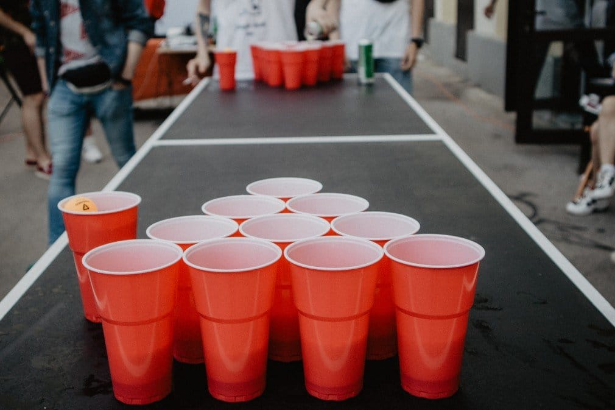

Typical Beer Pong Setup (credit:bargames101.com)

To study different intoxication levels, we prepare 3 dosage levels of 180 proof alcohol to achieve 0.03 (low), 0.06 (medium), and 0.10 (high) blood alcohol content (BAC) in subjects. For reference, 0.08 BAC is the federal threshold for criminal DUI in the United States. We recruit 4 drinking-age college students as subjects. Due to the ongoing coronavirus pandemic in the US, there was difficulty in recruiting more subjects. Dosages are customized for each subject given their body weight to achieve the desired BAC level using an [online calculator](http://www.clevelandclinic.org/health/interactive/alcohol_calculator.asp). Each dose is also mixed with sugary juice to cover up the alcoholic taste, so that the subject cannot reliably tell the alcoholic content by taste alone. Repeated measures are administered on each subjects, each receiving one dose of all three treatments in random order. This yields a Randomized Complete Block Design (RCBD) with $N=12$ reponses total, with each subject being considered a block. Each dose is administered on a different night to maintain independence between responses, and subjects are not informed of dosages until after experiment conclusion. Each subject is asked to wait for 30 mins after each dose in order to digest the ethanol. They also practice for around 5 minutes before measurements, to reduce the possible variance introduced by different levels of subject familiarity with the game. Each measurement is taken by recording the number of ping pong balls scored into a standard setup of 10 cups over 20 shots. For simplicity, subjects are asked to throw ping pong balls into the cups in succession, without drinking beer in between shots, and cups are not removed when they are scored, unlike the actual beer pong game.

## Experiment Results

### Data Table

```r
df = read.csv('pong.csv')
df$Dosage <- factor(df$Dosage, levels=c("Low", "Medium", "High"))

library(purrr)
library(reshape2)
transposed_data = dcast(df[c("Subject", "Dosage", "Score")], Subject~Dosage, value.var="Score")
rownames(transposed_data) = map(transposed_data[, 1], function(initial) paste("Subject ", initial))
colnames(transposed_data) = map(colnames(transposed_data), function(level) paste(level, " Dose"))
transposed_data[, 1] = NULL
library(knitr)
kable(transposed_data, caption="Beer Pong Scores")
```

Beer Pong Scores

|  | Low Dose | Medium Dose | High Dose |
| --- | --- | --- | --- |
| Subject B | 5 | 8 | 6 |
| Subject E | 8 | 8 | 7 |
| Subject N | 6 | 13 | 9 |
| Subject P | 5 | 10 | 4 |

### Visualization

First, let us visualize the data with a boxplot.

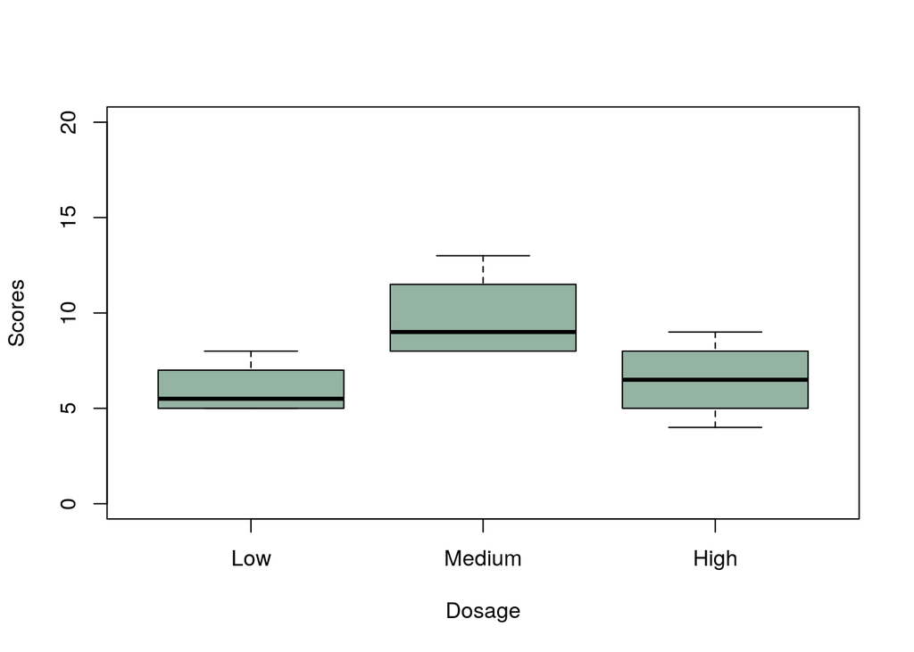

```r
dot_colors = rgb(0.3,0.5,0.4,0.6)
boxplot(df$Score ~ df$Dosage, col=dot_colors, ylab="Scores", xlab="Dosage", ylim=c(0, 20))
```

From above plot, we can see that medium dosage has the highest distribution of scores, which intuitively makes sense - the subjects might be drunk enough to be relaxed but not enough to significantly impair their senses. However, the differences might be caused by random statistical noise rather than actual dosage effects. We thus investigate whether the differences are statistically significant given our sample size.

### Hypothesis Testing

Our statistical model can be expressed as
$$y_{ij}=\mu + \tau_{i} + \beta_{j} + \epsilon_{ij}$$
where $y_{ij}$ and $\epsilon_{ij}$ are the score and random error for the $i$th treatment and $j$th subject respectively, $\mu$ is the mean beer pong score, $\tau_{i}$ is the $i$th treatment effect, $\beta_{j}$ is the $j$th block effect, and $1\leq i\leq3$, $1\leq j\leq4$. Our null hypothesis is
$$H_0: \tau_1 = \tau_2 = \tau_3$$

#### ANOVA test

Through analysis of variance (ANOVA) we detect statistically significant differences in average strength with $P(F>F_0 | H_0)=0.0412$.

```r
model = aov(Score ~ Dosage + Subject, data=df)
print(summary(model))
# EXPECTED CONSOLE OUTPUT
#             Df Sum Sq Mean Sq F value Pr(>F)
# Dosage       2  33.17  16.583   5.686 0.0412 *
# Subject      3  18.25   6.083   2.086 0.2036
# Residuals    6  17.50   2.917
# ---
# Signif. codes:  0 ‘***’ 0.001 ‘**’ 0.01 ‘*’ 0.05 ‘.’ 0.1 ‘ ’ 1
```

#### Treatment Comparisons

We can also use Tukey’s method to see which pairs of treatments have statistically different effects. Using a confidence level of 95%, we conclude that there is significant difference between medium dosage and low dosage, but the difference between estimated high and medium or high and low dosage effects are not large enough to be considered statistically significant with our sample size.

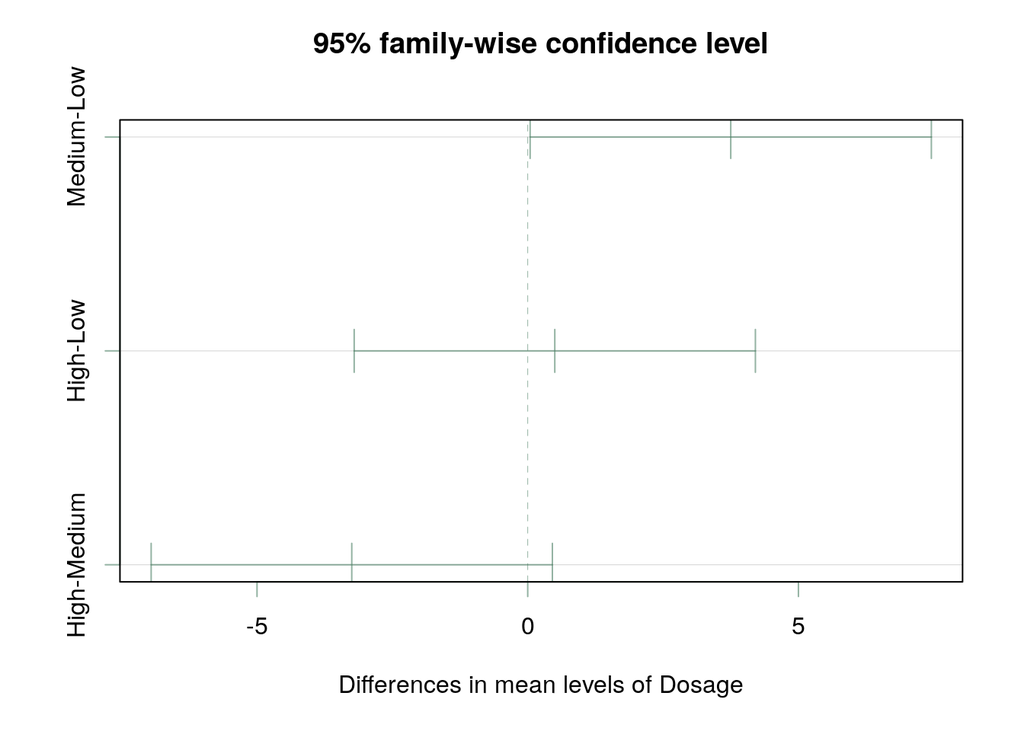

```r
library(multcompView)
tukey_comparisons = TukeyHSD(x=model, 'Dosage', conf.level=0.95)
plot(tukey_comparisons, col=dot_colors)
```

#### Model Adequacy

We check several assumptions to confirm the validity of our ANOVA test. Firstly, we check that the residuals are normally distributed. We see below that the quantiles of the residual roughly correspond to the theoretical normal distribution quantiles. Shapiro-wilk test also fails to reject the hypothesis that the residuals are normally distributed (p=0.35).

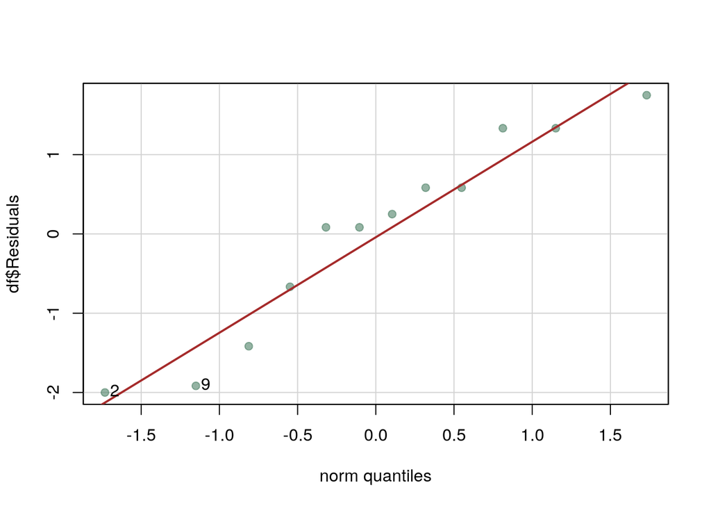

```r
df$Residuals = model$residuals
library(car)
qqPlot(df$Residuals, col=dot_colors, col.lines="brown", pch=19, envelope=FALSE)
```

```r
print(shapiro.test(df$Residuals))
# EXPECTED CONSOLE OUTPUT
# [1] 2 9
#
#   Shapiro-Wilk normality test
#
# data:  df$Residuals
# W = 0.9274, p-value = 0.3534
```

We then check that residuals have about the same variance with regard to each treatment level and subject. We see that there is no large deviations in between residual variances of different dosages. While it looks like high dosage measurements have slightly smaller residuals, as does subject B, the deviations are not large enough in magnitude to be considered statistically signifcant by Levene’s Test (p=0.69, p=0.52).

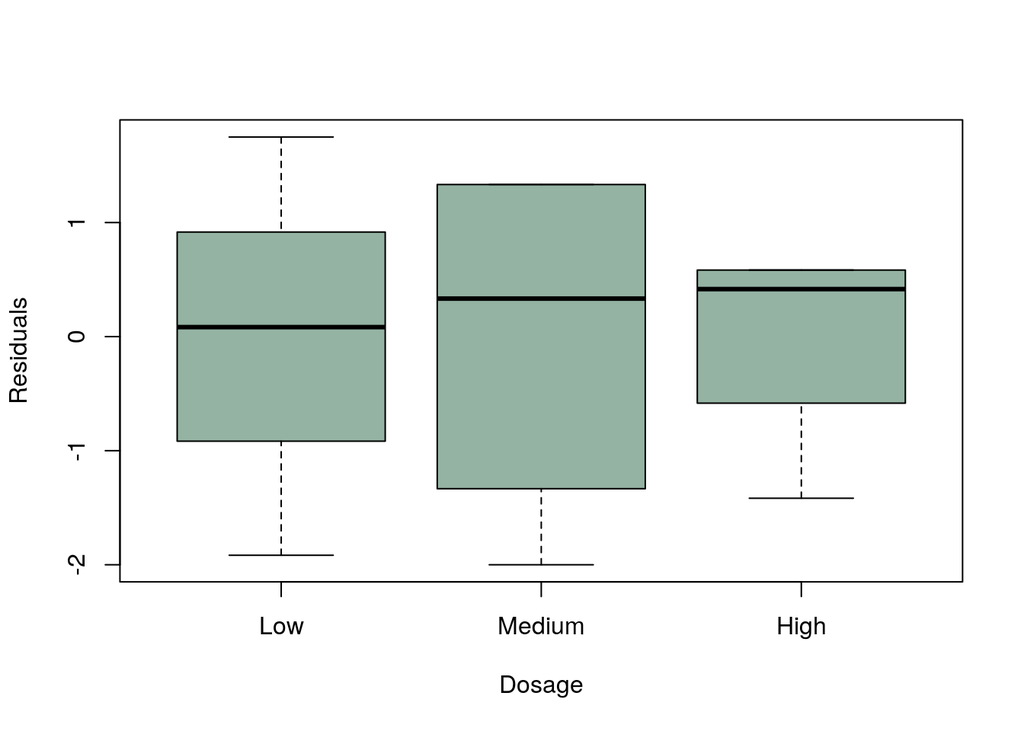

```r
boxplot(Residuals~Dosage, data=df, col=dot_colors)
```

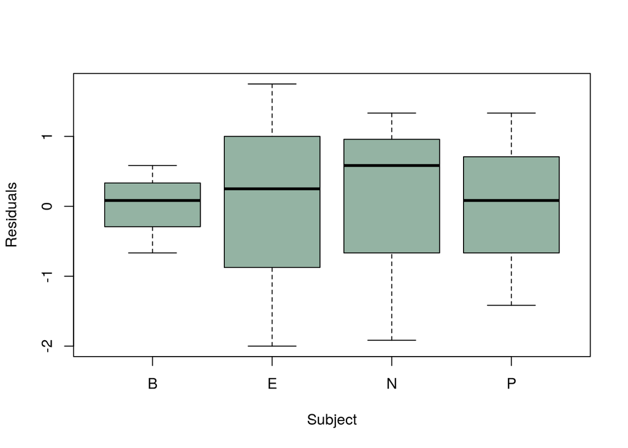

```r
print(leveneTest(Score~Dosage, data=df))
boxplot(Residuals~Subject, data=df, col=dot_colors)
```

```r
print(leveneTest(Score~Subject, data=df))
# EXPECTED CONSOLE OUTPUT
# Levene's Test for Homogeneity of Variance (center = median)
#       Df F value Pr(>F)
# group  2  0.3818 0.6932
#        9
# Levene's Test for Homogeneity of Variance (center = median)
#       Df F value Pr(>F)
# group  3  0.7982 0.5287
#        8
```

We also visualize model residuals over scores to check for irregularities.

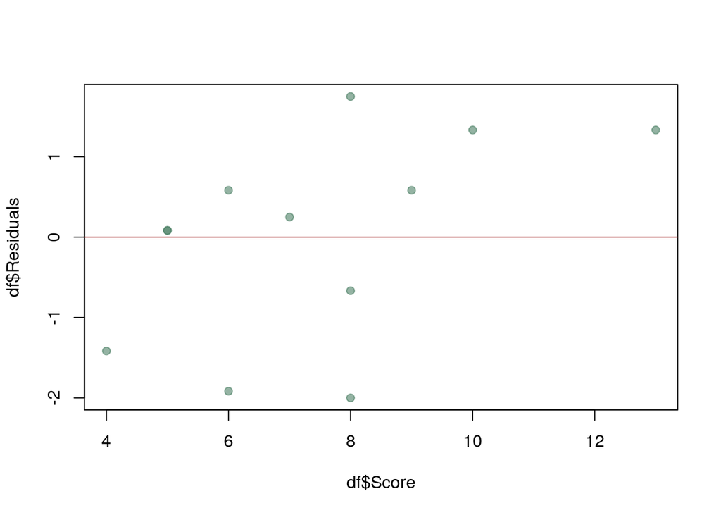

```r
plot(df$Score, df$Residuals, col=dot_colors, pch=19)
abline(h=0,col="brown")
```

There appears to be no obvious relationship between the score measured and the model residuals.

Lastly, we visualize model residuals over the order at which the subject receives the dose.

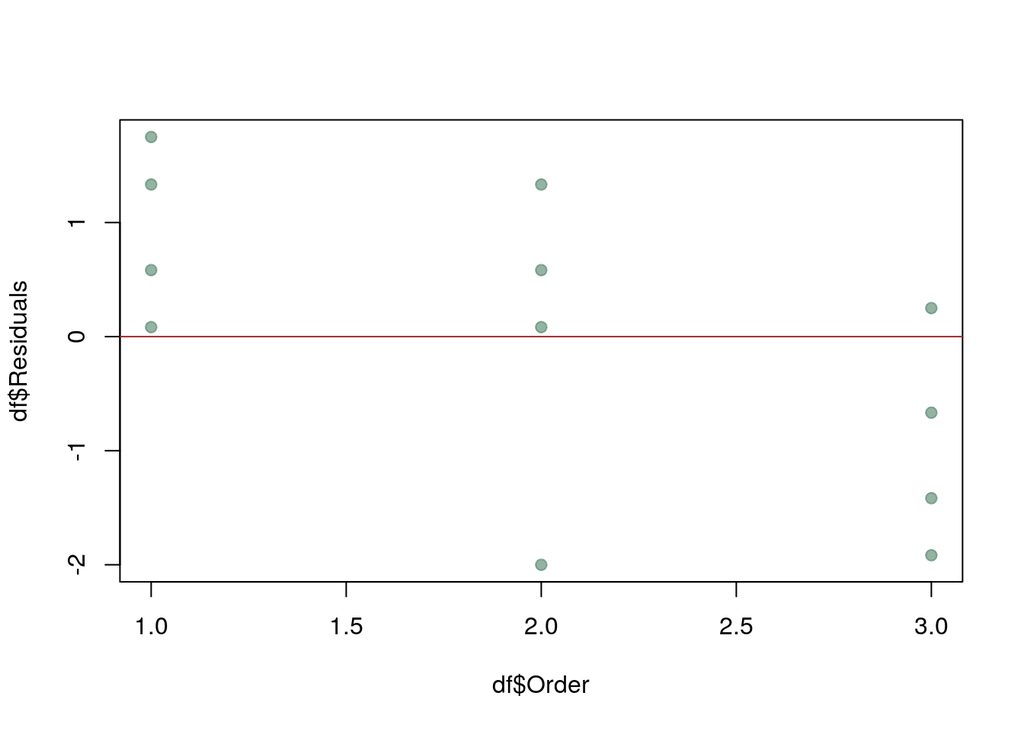

```r
plot(df$Order, df$Residuals, col=dot_colors, pch=19)
abline(h=0,col="brown")
```

There appears to be a strong negative relationship between residuals and the dose order. This suggests that subjects perform worse as time goes on. It might be explained by increased fatigue or boredom with playing beer pong in an experimental setting, over 3 consecutive days. Luckily, the order for each treatment is randomized and thus this finding does not affect the validity of our statistical analysis.

## Summary

To summarize, we find evidence that there is an optimal strategy for consuming alcohol to achieve the best performance on beer pong games, and it may not be consuming as much as possible or as little as possible, but somewhere in between. While we only have 12 measurements, the differences are large enough to be statistiscally significant. We hope that this inspires future research into finding the optimal level of intoxication for various tasks.